# 10 Exercise 9: Using Woodlot to Forecast Small Land Areas

Author

Sarah Smith-Tripp

## Background & Overview

The goal is for you to become familiar with how forecast models work for a medium-sized land area, and how you can forecast the future forecast using a tool, in this case, Woodlot. You will simulate three forest management scenarios, compare the outcomes, and suggest another scenario that you might want to do based on the outputs obtained for these three scenarios.

## Learning Objectives

- Become familiar with how forecasts models work using a medium-sized land area
- How you can forecast the future under different management options (scenarios) using a software tool

## Assignment Introduction

Background to Woodlot software:

• Woodlot allows you to bring in the vegetation cover polygon data for the BC forest inventory and directly link these to VDYP pre-harvest and to VDYP or TIPSY post-harvest. However, other yield tables (e.g., from MGM or PrognosisBC) could be used via over-riding VDYP and TIPSY direct links to each stand. • Woodlot also removes lakes and other areas that are not forested; removals of entire polygons or parts of polygons in analyses are also possible. • Woodlot provides a spatial map of different management scenarios that you might run, along with summary tables and graphs that are useful. • HOWEVER, Woodlot does not simulate *adjacency constraints*. For example, if any area is harvested, it is possible that the neighboring area will be harvested in the next time period. Further, there still are some limits to what else you can do using Woodlot.

## Loading Data in Woodlot

### 10.0.1 Background processing done for the 2020 file

To import data into Woodlot we can use the VRI layer 1 data. In this case, the data we are working with is 2020 VRI data. To prepare this data for use in Woodlot there are several important teps. 1. Woodlot can technically take as many polygons as your give it, but we are interested in MKRF specifically so we clipped to the MRKF boundary. 2. Woodlot has some specifics for attribute names that do not work with the VRI data, we have updated these here. 3. Date fields were converted into text format. 4. The data and its .dbf filter were exported from a geodatabase.

### 10.0.2 Loading class data into Woodlot

1. Open Woodlot 4.4
2. Select “coast” as the region and “CWH” as the BEC zone.

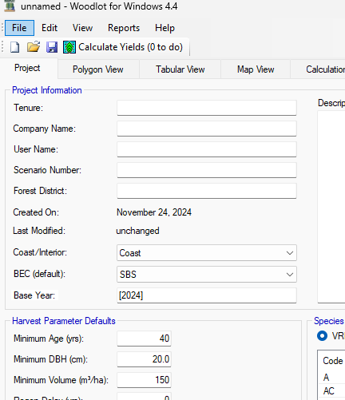

3. Import the MKRF data by going to File -> Import

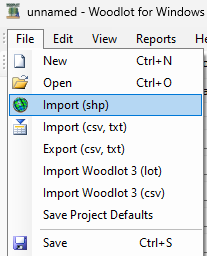

4. You will get a window that looks like this click “import” . There will be 458 polygons from MKRF loaded into the software.

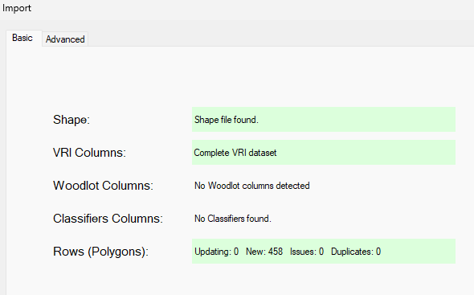

## Forest Harvesting Scenarios

For this lab, we will compare the outputs of three different forest harvesting scenarios. These forest harvesting scenarios are:

**Scenario 1**

Minimum Age for harvest is 60 years

Minimum DBH for harvest is 50 cm DBH

Minimum merchantable volume/ha for harvest is 350 m3/ha

Regeneration Delay is 5 years

Post-harvest yields will be forecasted using VDYP assuming the stand will achieve the same yields and be the same species composition as pre-harvest yields

**Scenario 2**

This scenario will set the AAC instead of letting this be autocalculated. It will be much higher

**Scenario 3**

Alter the eligibility criteria.

Stands must have a minimum DBH with 40 cm

Stands have a minimum volume of 200 m3/ha before they can be eligible for harvest

## Scenario 1.

1. Name the project to align with the scenario “Scenario 1” and input some information on the scenario in the descriptions tabl

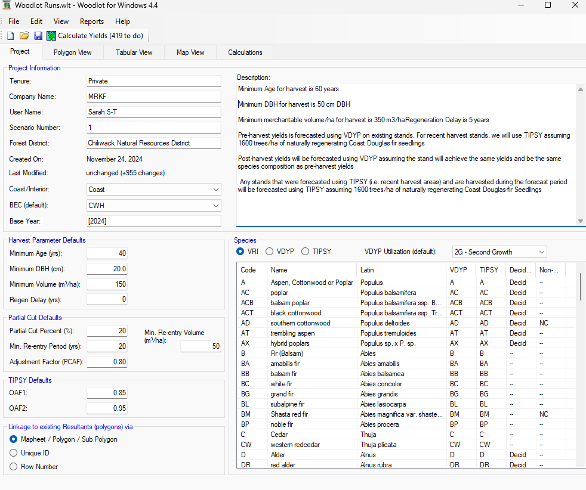

2. Adjust the harvest parameter defaults.
   1. Minimum age is 60 years.
   2. Minimum DBH is 50 cm
   3. Minimum volume is 350 m3/ ha
   4. Regen delay is 5 years
   5. **note there is no need to adjust TIPSY or partial cut defaults**

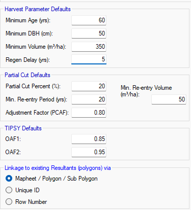

3. Change VDYP utilization to 12.5 cm

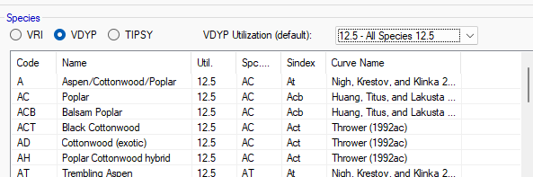

4. Calculate yields for each polygon
   1. Before harvesting, we will use VDYP for unmanaged stands. Except where the stands are recently harvested, where we will use TIPSY.
   2. Post-harvest, yields will be forecast again using VDYP assuming the stand will be identical to the stand pre-harvest, but just starting again at stand age=0. Again, the exception is stands that were recently harvested. These will be forecasted post-harvest again using TIPSY.
   3. Click on the “Calculate Yields” button to use VDYP to forecast the existing stands.
      1. This will run VDYP for each stand using the critical VRI forest attributes to drive VDYP (as you did for three polygons in Exercise 6, but you did that manually entering in the needed VRI attributes into VDYP).
5. After calculation, there are some polygons left to forecast. A place for us to investigate more!
6. Click on the Polygon View tab
7. Collapse the non-FMLB folders and the FMLB folder in the Polygons list. Of the 458 polygons, there are 419 FMLB polygons and the remaining polygons are non-FMLB polygons, grouped into four types (lakes, etc.) (See screenshot next page).

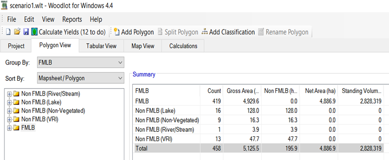

8. **Expand the Non-FMLB folders** and **double-click on the first of the non-FMLB (Lake) polygons. Click on the buttons (Small map, Comments, etc.)** to see the map of that polygon, as well as some of the attributes. **NOTE: The selected polygons will show up with a “hatched” symbol. To remove this symbol, double-click on the polygon symbol and it will go back to the original symbol. ALSO, at any time you can see the full map of all polygons by clicking on the “Map View” tab.**
   1. You should now have a screen that looks like this:

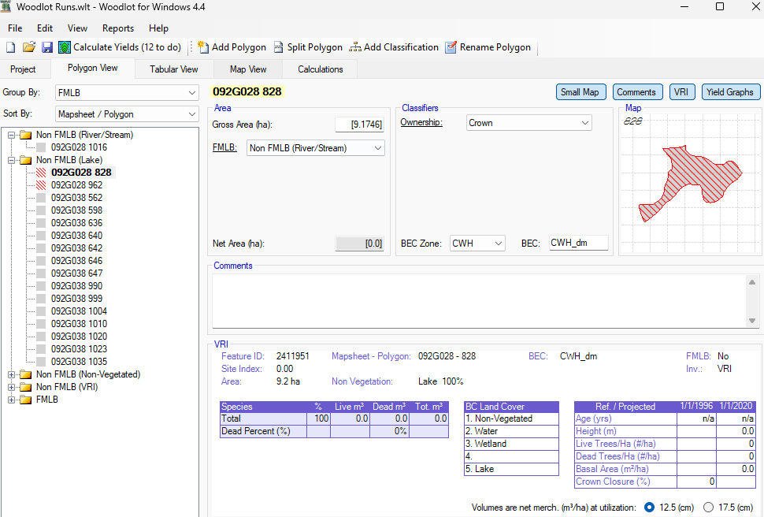

### Q2.

**Deselect this lake polygon and choose another lake polygon. Provide a screenshot, and add a sentence that notes the size of the lake and the BC landcover type.**

### Q3.

**When we first forecasted using VDYP we did so for 419 polygons. Why are there only 419 polygons out of 458 to forecast?**

### Q4.

**What are the BC land cover types for these Non-vegetated polygons? Write down the polygon numbers and the land cover types (i.e., the five land cover class levels) for polygons 444, 488, 517, and 978.**

### Q5.

**Check polygon 509. Why was this included in the non-FMLB (Non-vegetated) list of polygons? Could it have been included in the non-FMLB (VRI) list? What about the FMLB list? Use the information you have for this polygon as evidence to support your answer.**

### Q6.

**What are the BC land cover types for these non-FMLB (VRI) polygons? Write down the polygon number and land cover types for polygons 540, 754, and 1012.**

### Q7.

**Could any of these non-FMLB (VRI) polygons be forested in the future? Consider what would have to be done in the way of management interventions and the cost of these interventions (in a general way, not with specific costs) to create a forested polygon for some of these non-FMLB polygons in your answer.**

10. Collapse the non-FMLB folder and expand the FMLB folder. Look at the list of polygons that are part of the FMLB. You will see that some of them have the symbol (box) colored green and some are brown (or could be blue). Others have a question mark.
    1. **Green polygons**: The green ones are polygons that meet the minimum harvest criteria that you set (e.g., minimum DBH and volume per ha) without management interventions (i.e., can be harvested sometime in the forecast period). The yields of the current stand were obtained using VDYP. The assumed harvest was clearcut and post-harvest, the yields would be forecasted using VDYP assuming the stand would be eventually identical to the stand pre-harvest. This could be changed to use TIPSY post-harvest and simulate a planted/naturally regenerated stand with different characteristics than pre-harvest, or using VDYP for partial harvests (via a process that gives approximate yield post-harvest).
    2. **Brown (or blue?) polygons**: The brown (or blue?) polygons do not meet the minimum harvest criteria set within the harvest period (e.g., never reach 350 m3/ha or do not reach the min. DBH required), OR are currently NSR or NC: i. NSR: Not Satisfactorily Restocked. These sites are considered productive, but not currently restocked. You can choose to Restock the stand and indicate the regeneration delay (when will regeneration occur?), and then by indicating the numbers of types of planted or natural trees. These stands would then be forecasted using TIPSY. (Not done in Scenario 1). ii. NC: Non-Commercial Cover. These are areas that are “non-commercial or damaged sites” that could be converted to productive forests. You would specify “Reforest” which would begin with removal of all trees as part of the stand conversion. TIPSY or VDYP can be used to forecast the future forest. (Not done in Scenario 1).
    3. **Polygons with a question mark**: The polygons with a question mark (12 of these…. remember 12 polygons were left to forecast out of the 419 FMLB polygons) are likely recent harvests. There is no VDYP forecast for these polygons since VDYP requires the species composition, site index, crown closure, and age as the minimum inputs to forecast the yields of an existing stand. You will need to fix each one of these to use TIPSY instead.
11. Double-click on a few of the green-colored FMLB polygons to see the current VRI information as well as the forecasted yields. For example, for Polygon 456, here are two screenshots:

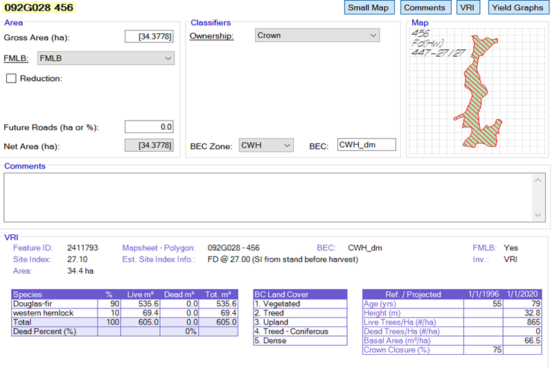

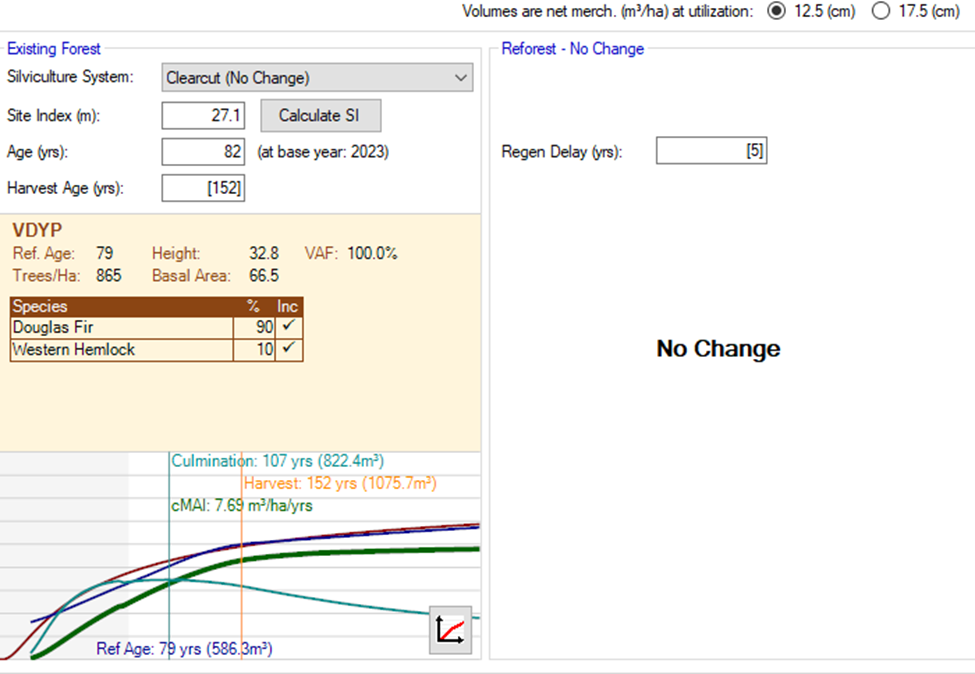

12. **Important NOTE on ages:** In the graph, there are **three ages:** 1) “**Harvest age**” is when the stand meets the harvest criteria you set in the Project panel; 2) “**Culmination Age**” (i.e., *biological rotation age* at maximum m.a.i.); and 3) “**Reference age**” which is age of this stand in 2020 (the date for the VRI projected data) ..!). The stand could be harvested by *Woodlot* at the “Harvest Age” or the culmination age, *whichever is greater*!
13. We can control a lot in protocols for example . For example, if we wanted to add an area for reserves we could reduct the areas as follows:

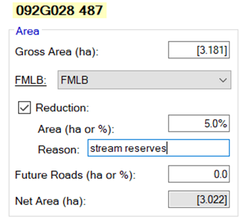

[figure not shown]

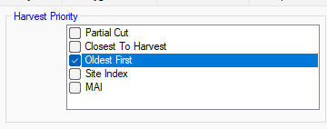

    This creates a harvest schedule list of polygons in order of harvest, including harvest starts and stops, the age, and the volume that would be harvested (screenshot next). You can click on other items to get more information as well.
29. Then**, click on Calculate and leave this as Auto – Harvest Rate (m<sup>3</sup>/year) at the bottom of the screen.**
30. This creates a harvest schedule list of polygons in order of harvest, including harvest starts and stops, the age, and the volume that would be harvested (screenshot next). You can click on other items to get more information as well. **You can also click on each polygon and see where that polygon is planned for harvesting**

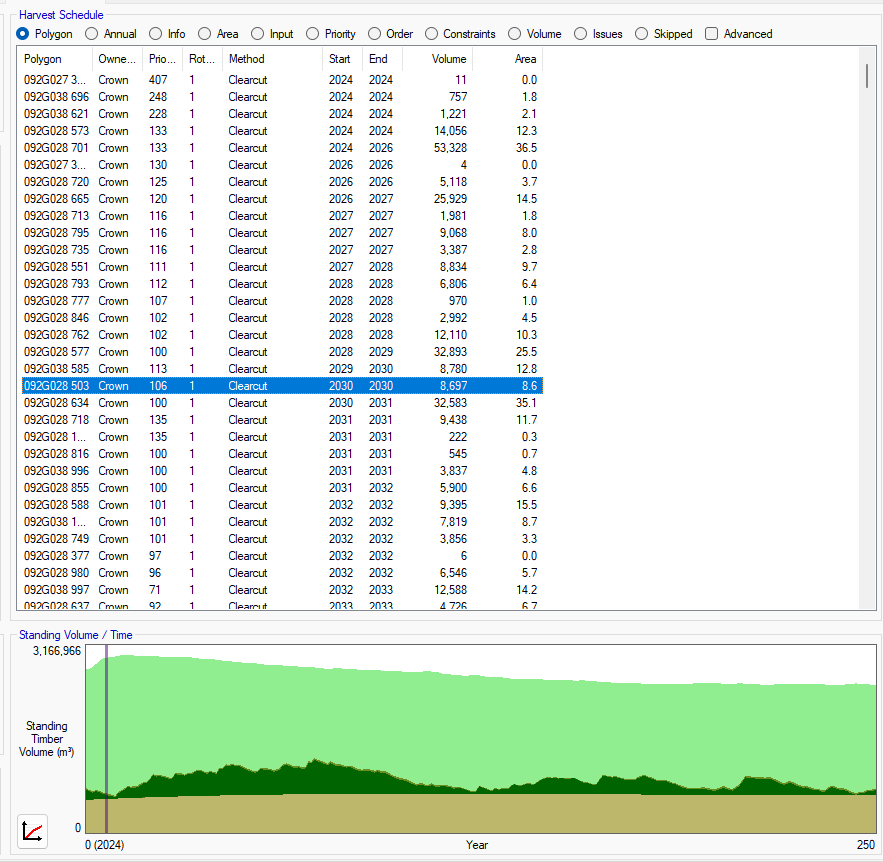

31. The graph included above is a stacked graph of non-harvestable volume (the bottom line) + mature timber (middle line) + immature volume (top line).
32. We also see that the AAC and the LRSY are included at the base

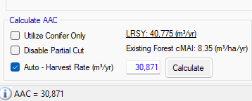

33. **Click on the Plotsy icon** to get a better graph of the Standing Volume over time

### Q8.

**What was the AAC for Scenario 1?**

### Q9.

**For Scenario 1, add captions to your screenshot of the volume stocks forecast in your Ex9 WORD file (i.e., Figure 1) and to your screenshot of the age distribution over time in your Ex9 WORD file.**

### Q10.

**What happened in this forecasted management scenario? Refer to your stocks over time and age distribution over time graphs, and your scenario1.docx Woodlot report in answering these questions.1) Were the volume stocks maintained over time (i.e., almost the same at the beginning and end of the forecast period) or were they lower or higher at the end of the period than at the start of the period? How much were these stocks over time? 2) What happened to the age class distribution at the beginning of the forecast period (which bar color for Year 0) versus the end of the forecast period (which color for Year 250)?**

## Scenario 2.

### Q11.

**What was the AAC for Scenario 2? Briefly explain why this differs from Scenario 1.**

### Q12.

**Add a figure number and a caption to your screenshot of the volume stocks forecast in your Ex9 WORD file.**

## Scenario 3.

For Scenario 3, you will again forecast post-harvest using VDYP and cut the oldest first out of the stands the meet the eligibility criteria in Scenarios 1 and 2, but you will again allow Woodlot to calculate the AAC as in Scenario 1. Further, you will change the eligibility criteria to be:

1. The utilization level for VDYP will be set to 12.5 cm DBH + (no change).
2. Stands must be at least 60 years (no change), with a minimum DBH of 40 cm (lower), and a minimum volume of 200 m<sup>3</sup>/ha (for all trees 12.5 cm DBH+, lower) before they can be eligible for harvest.
3. The regeneration delay (i.e., time before new trees become established) is 5 years (no change).
4. VDYP and TIPSY will be used as in Scenarios 1 and 2 (no change).
5. Stands eligible to harvest will be selected using “oldest first” (no change).
6. The AAC will be calculated by Woodlot (no change).

*Steps to run Woodlot for Scenarios 3*

1. **Go back to the Project tab** and change this to Scenario 3, the Harvest Criteria to 60 years, 40 cm DBH, 200 m<sup>3</sup>/ha, and 5 years regen delay.
2. Save this project as **scenario3.wlt** 3.
3. Then, click on **Calculate Yields first.**
4. 4.**Then click on the Calculate Tab,**
5. **First, change this back to Auto (i.e., add the check mark again and calculate the AAC).**
6. **Click on the Plotsy icon** to get a better graph of the Standing Volume over time Take a screen shot of your graph and add this to your **Ex9** WORD file.
7. **Click on Reports and create Woodlot Report**. This prepares a document for you (an .rtf file than can be saved as a .docx file) with some outputs already entered into the report. Save your Woodlot report in **Scenario3.docx**

### Q14.

**What was the AAC for Scenario 3, which had a lower minimum merchantable volume/ha and lower minimum average DBH criteria for harvest eligibility?**

### Q15.

**Add a label and caption to your screenshot of the volume stocks forecast in your Ex9 WORD file.**

### Q16.

**Were the volume stocks maintained over time (i.e., almost the same at the beginning and end of the forecast period) or were they lower or higher at the end of the period than at the start of the period? Refer to your stocks over time graph in answering this question.**

## Summarize across scenarios.

### Q17.

**What were the main differences in the scenarios? Write up 1-2 paragraphs comparing the scenarios. Also, indicate which of these three scenarios you would recommend and justify your choice. Finally, recommend an alternative scenario that you might want to consider running, and why you might want to run this scenario (no need to run this in Woodlot, though).**

## Lab Questions & Deliverables

1. How big is this lake? What is the BC landcover type for this lake polygon? You can use the VRI information to understand this. Note, there are five different land cover classes that go from general to specific.
2. Deselect this lake polygon and choose another lake polygon. Provide a screenshot, and add a sentence that notes the size of the lake and the BC landcover type.
3. When we first forecasted using VDYP we did so for 419 polygons. Why are there only 419 polygons out of 458 to forecast?
4. What are the BC land cover types for these Non-vegetated polygons? Write down the polygon numbers and the land cover types (i.e., the five land cover class levels) for polygons 444, 488, 517, and 978.
5. Check polygon 509. Why was this included in the non-FMLB (Non-vegetated) list of polygons? Could it have been included in the non-FMLB (VRI) list? What about the FMLB list? Use the information you have for this polygon as evidence to support your answer.
6. What are the BC land cover types for these non-FMLB (VRI) polygons? Write down the polygon number and land cover types for polygons 540, 754, and 1012.
7. Could any of these non-FMLB (VRI) polygons be forested in the future? Consider what would have to be done in the way of management interventions and the cost of these interventions (in a general way, not with specific costs) to create a forested polygon for some of these non-FMLB polygons in your answer.
8. What was the AAC for Scenario 1?
9. For scenario 1, add captions to your screen shot of the volume stocks forecast in your **Ex9** WORD file (i.e., Figure 1 ??add the description?) and to your screen shot of the age distribution over time in your Ex9 WORD file.
10. What happened in this forecasted management scenario? Refer to your stocks over time and age distribution over time graphs, and your scenario1.docx Woodlot report in answering these questions.1) Were the volume stocks maintained over time (i.e., almost the same at the beginning and end of the forecast period) or were they lower or higher at the end of the period than at the start of the period? How much were these stocks over time? 2) What happened to the age class distribution at the beginning of the forecast period (which bar color for Year 0) versus the end of the forecast period (which color for Year 250)?
11. What was the AAC for Scenario 2? Briefly explain why this differs from Scenario 1.
12. Add a figure number and a caption to your screen shot of the volume stocks forecast in your **Ex9** file.
13. Were the volume stocks maintained over time (i.e., almost the same at the beginning and end of the forecast period) or were they lower or higher at the end of the period than at the start of the period? Refer to your stocks over time graph in answering this question.
14. What was the AAC for Scenario 3, which had a lower minimum merchantable volume/ha and lower minimum average DBH criteria for harvest eligibility?
15. Add a label a caption to your screen shot of the volume stocks forecast in your **Ex9** WORD file.
16. Were the volume stocks maintained over time (i.e., almost the same at the beginning and end of the forecast period) or were they lower or higher at the end of the period than at the start of the period? Refer to your stocks over time graph in answering this question.
17. What were the main differences in the scenarios? Write up 1-2 paragraphs comparing the scenarios. Also, indicate which of these three scenarios you would recommend and justify your choice. Finally, recommend an alternative scenario that you might want to consider running, and why you might want to run this scenario (no need to run this in Woodlot, though).

## Summary

We learned how to use woodlot to answer important forest management questions - including comparing across scenarios and seeing how this impacts AAC. What a great tool!